# Density Estimation Demo

| shot_x | shot_y | shot_distance | is_shot_made | period | fg_type | shot_zone | shot_type |
| --- | --- | --- | --- | --- | --- | --- | --- |
| -3 | 34 | 3 | FALSE | 1 | 2PT Field Goal | Restricted Area | Layup Shot |
| 6 | 10 | 1 | TRUE | 1 | 2PT Field Goal | Restricted Area | Dunk Shot |
| -14 | 20 | 2 | FALSE | 1 | 2PT Field Goal | Restricted Area | Driving Layup Shot |
| -131 | 235 | 26 | FALSE | 1 | 3PT Field Goal | Above the Break 3 | Pullup Jump shot |
| 36 | 33 | 4 | FALSE | 1 | 2PT Field Goal | In The Paint (Non-RA) | Layup Shot |
| 26 | 259 | 26 | FALSE | 2 | 3PT Field Goal | Above the Break 3 | Pullup Jump shot |

```r
giannis_shots %>%
  ggplot(aes(x = shot_distance)) +
  geom_histogram(binwidth = 1,
                 center = 0.5,
                 closed = "left") +
  theme_bw()
```

[output not shown]

Probability density function (PDF) is the derivative of the cumulative distribution function (CDF).

Histograms approximate the PDF with bins, and points are equally likely within a bin. (probability of a realization occuring within a bin follows a uniform distribution)

We want non-zero density between our observations, e.g. between 23 and 24 feet

## Kernel Density Estimation (KDE)

**Goal**: Estimate the PDF $f(x)$ for all possible values (assuming it is continuous / smooth)

Kernel density estimate: $f\hat(x) = \frac{1}{n}\displaystyle\sum^{n}_{i=1}\frac{1}{h}K_h(x-x_i)$

$n$: sample size, $x$: new point to esimate $f(x)$ (does NOT have to be in dataset!)

$h$: bandwidth, analogous to histogram bin width, ensures $f\hat(x)$ integrates to 1

$x_i$: ith observation in dataset

$K_h(x-x_i)$ is the Kernel function, creates weight given distance of ith observation from new points

as $|x - x_i| \rightarrow \infty$ then $K_h(x-x_i) \rightarrow 0$

Generally use the Gaussian kernel (normal distribution PDF) with variance = $h$

```r
giannis_shots %>%
  ggplot(aes(x = shot_distance)) +
  geom_density() +
  geom_rug(alpha = 0.3) +
  theme_bw()
```

[output not shown]

Use Gaussian reference rule (rule of thumb), $1.06\sigma n^{-\frac{1}{5}}$ where $\sigma$ is the observed standard deviation. This is the default bandwidth in R.

```r
# adjust multiplies the default bandwidth
giannis_shots %>%
  ggplot(aes(x = shot_distance)) +
  geom_density(adjust = 0.5) +
  geom_rug(alpha = 0.3) + theme_bw()
```

[output not shown]

Use density curves and ECDF together!

```r
library(patchwork)

giannis_shot_dens <- giannis_shots %>%
  ggplot(aes(x = shot_distance, color = is_shot_made)) +
  geom_density(adjust = 0.5) +
  geom_rug(alpha = 0.3) +
  theme_bw() +
  labs(x = "Shot distance (in feet)",
       y = "Density") +
  theme(legend.position = "none")

giannis_shot_ecdf <- giannis_shots %>%
  ggplot(aes(x = shot_distance, color = is_shot_made)) +
  stat_ecdf() +
  geom_rug(alpha = 0.3) +
  theme_bw() +
  labs(x = "Shot distance (in feet)",
       y = "Proportion of Giannis' shot attempts")

giannis_shot_dens / giannis_shot_ecdf + plot_layout(guides = "collect")
# stack on top: giannis_shot_dens / giannis_shot_ecdf
```

[output not shown]

```r
library(ggridges)

giannis_shots %>%
  ggplot(aes(x = shot_distance,
             y = shot_type)) +
  geom_density_ridges(rel_min_height = 0.01) +
  theme_bw()
```

[output not shown]

```r
giannis_shots %>%
  mutate(shot_x = -shot_x / 10,
         shot_y = shot_y / 10) %>%
  filter(shot_y <= 30) %>%
  ggplot(aes(x = shot_x, y = shot_y)) +
  geom_point(alpha = 0.3) +
  geom_density_2d(adjust = 0.1) +
  theme_bw() +
  coord_fixed()
```

[output not shown]

```r
giannis_shots %>%
  mutate(shot_x = -shot_x / 10,
         shot_y = shot_y / 10) %>%
  filter(shot_y <= 30) %>%
  ggplot(aes(x = shot_x, y = shot_y)) +
  stat_density2d(h = 0.5, bins = 60,
                 aes(fill = after_stat(level)),
                 geom = "polygon") +
  scale_fill_gradient(low = "darkblue",
                      high = "darkorange") +
  theme_bw() +
  theme(legend.position = "bottom") +
  coord_fixed()
```

[output not shown]

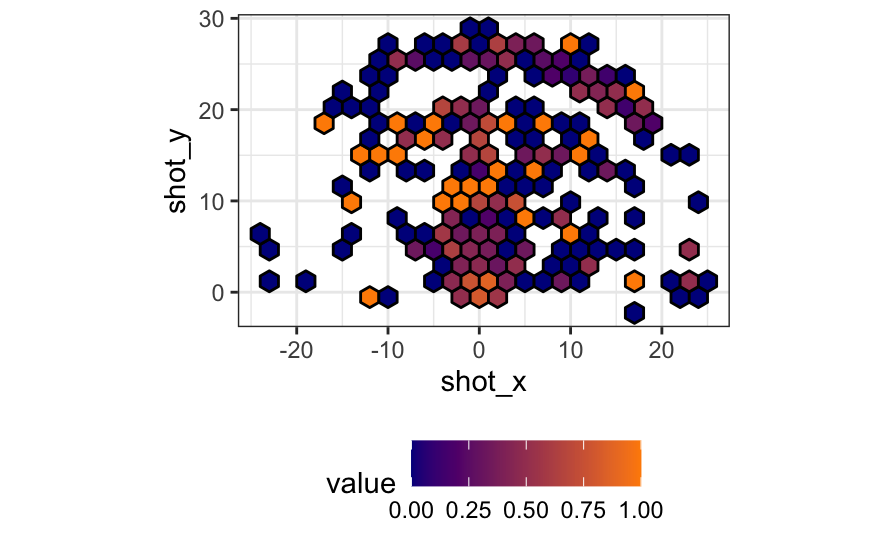

```r
giannis_shots %>%
  mutate(shot_x = -shot_x / 10,
         shot_y = shot_y / 10) %>%
  filter(shot_y <= 30) %>%
  ggplot(aes(x = shot_x, y = shot_y, z = is_shot_made, group = -1)) +
  stat_summary_hex(binwidth = c(2, 2),
                   color = "black",
                   fun = mean) +
  scale_fill_gradient(low = "darkblue",
                      high = "darkorange") +
  theme_bw() +
  theme(legend.position = "bottom") +
  coord_fixed()
```